# Project 1

Aleksei Sivtsev

2023-10-05

```r
# install.packages("nortest")
#library(nortest)
library(dplyr)
```

```r
library(ggplot2)
library(knitr)
main_dir <- dirname(rstudioapi::getSourceEditorContext()$path)
setwd(main_dir)
```

### Обзор данных

```r
day <- read.csv('day.csv', na.strings=c("","NA"))
str(day)
```

```
## 'data.frame':    731 obs. of  16 variables:
##  $ instant   : int  1 2 3 4 5 6 7 8 9 10 ...
##  $ dteday    : chr  "2011-01-01" "2011-01-02" "2011-01-03" "2011-01-04" ...
##  $ season    : int  1 1 1 1 1 1 1 1 1 1 ...
##  $ yr        : int  0 0 0 0 0 0 0 0 0 0 ...
##  $ mnth      : int  1 1 1 1 1 1 1 1 1 1 ...
##  $ holiday   : int  0 0 0 0 0 0 0 0 0 0 ...
##  $ weekday   : int  6 0 1 2 3 4 5 6 0 1 ...
##  $ workingday: int  0 0 1 1 1 1 1 0 0 1 ...
##  $ weathersit: int  2 2 1 1 1 1 2 2 1 1 ...
##  $ temp      : num  0.344 0.363 NA 0.2 0.227 ...
##  $ atemp     : num  0.364 0.354 0.189 0.212 0.229 ...
##  $ hum       : num  0.806 0.696 0.437 0.59 0.437 ...
##  $ windspeed : num  0.16 0.249 0.248 0.16 0.187 ...
##  $ casual    : int  331 131 120 108 82 88 148 68 54 41 ...
##  $ registered: int  654 670 1229 1454 1518 1518 1362 891 768 1280 ...
##  $ cnt       : int  985 801 1349 1562 1600 1606 1510 959 822 1321 ...
```

Какие переменные у нас есть:

instant: индекс записи

dteday: дата

season: сезон (1:весна, 2:лето, 3:осень, 4:зима)

yr: год (0: 2011, 1:2012)

mnth: месяц

holiday: праздничный день

weekday: день недели

workingday: рабочий день, если день не выходной и не праздничный, то 1, в ином случае 0

weathersit:

- 1: Ясно, малооблачно, переменная облачность
- 2: Туман + обалчно, туман + облачно с прояснениями, туман + облачно с прояснениями, туман + малооблачно, туман
- 3: небольшой снег, небольшой дождь + гроза + облачно с прояснениями, небольшой дождь + облачно с прояснениями
- 4: Ливень + дождь со снегом + гроза + туман, снег + плотный туман (мгла)

temp: Нормализованная температура в градусах Цельсия. Значения делятся на 41 (макс.)

atemp: Нормализованная температура по ощущениям в градусах Цельсия. Значения делятся на 50 (макс.)

hum: Нормализованная влажность. Значения разделены на 100 (макс.)

windspeed: Нормализованная скорость ветра. Значения разделены на 67 (макс.)

casual: количество случайных пользователей

registered: количество зарегестрированных пользователей

cnt: количество взятых напрокат велосипедов, включая как случайные, так и зарегистрированные

### Работа с пропущенными значениями

Начнём с того, что проверим сколько у нас пропущенных значений. В наших данных 9 пропущенных значений

Исключим пропущенные значения из наших данных:

```r
day_without_na <- na.omit(day)
summary(day_without_na)
```

```
##     instant         dteday              season            yr
##  Min.   :  1.0   Length:722         Min.   :1.000   Min.   :0.0000
##  1st Qu.:187.2   Class :character   1st Qu.:2.000   1st Qu.:0.0000
##  Median :367.5   Mode  :character   Median :3.000   Median :1.0000
##  Mean   :367.1                      Mean   :2.504   Mean   :0.5028
##  3rd Qu.:547.8                      3rd Qu.:3.000   3rd Qu.:1.0000
##  Max.   :731.0                      Max.   :4.000   Max.   :1.0000
##       mnth           holiday           weekday        workingday
##  Min.   : 1.000   Min.   :0.00000   Min.   :0.000   Min.   :0.0000
##  1st Qu.: 4.000   1st Qu.:0.00000   1st Qu.:1.000   1st Qu.:0.0000
##  Median : 7.000   Median :0.00000   Median :3.000   Median :1.0000
##  Mean   : 6.532   Mean   :0.02909   Mean   :2.994   Mean   :0.6828
##  3rd Qu.: 9.750   3rd Qu.:0.00000   3rd Qu.:5.000   3rd Qu.:1.0000
##  Max.   :12.000   Max.   :1.00000   Max.   :6.000   Max.   :1.0000
##    weathersit         temp             atemp              hum
##  Min.   :1.000   Min.   :0.05913   Min.   :0.07907   Min.   :0.0000
##  1st Qu.:1.000   1st Qu.:0.34167   1st Qu.:0.33932   1st Qu.:0.5194
##  Median :1.000   Median :0.50250   Median :0.48969   Median :0.6300
##  Mean   :1.396   Mean   :0.49723   Mean   :0.47609   Mean   :0.6283
##  3rd Qu.:2.000   3rd Qu.:0.65562   3rd Qu.:0.60892   3rd Qu.:0.7310
##  Max.   :3.000   Max.   :0.86167   Max.   :0.84090   Max.   :0.9725
##    windspeed           casual         registered        cnt
##  Min.   :0.02239   Min.   :   2.0   Min.   :  20   Min.   :  22
##  1st Qu.:0.13495   1st Qu.: 317.2   1st Qu.:2507   1st Qu.:3196
##  Median :0.18129   Median : 725.5   Median :3664   Median :4566
##  Mean   :0.19049   Mean   : 853.9   Mean   :3671   Mean   :4525
##  3rd Qu.:0.23321   3rd Qu.:1099.2   3rd Qu.:4806   3rd Qu.:5990
##  Max.   :0.50746   Max.   :3410.0   Max.   :6946   Max.   :8714
```

### Категориальные величины

Конвертируем категориальными величинами в фактор:

```r
day_without_na$season <- as.factor(day_without_na$season)
day_without_na$weathersit <- as.factor(day_without_na$weathersit)
summary(day_without_na)
```

```
##     instant         dteday          season        yr              mnth
##  Min.   :  1.0   Length:722         1:176   Min.   :0.0000   Min.   : 1.000
##  1st Qu.:187.2   Class :character   2:182   1st Qu.:0.0000   1st Qu.: 4.000
##  Median :367.5   Mode  :character   3:188   Median :1.0000   Median : 7.000
##  Mean   :367.1                      4:176   Mean   :0.5028   Mean   : 6.532
##  3rd Qu.:547.8                              3rd Qu.:1.0000   3rd Qu.: 9.750
##  Max.   :731.0                              Max.   :1.0000   Max.   :12.000
##     holiday           weekday        workingday     weathersit
##  Min.   :0.00000   Min.   :0.000   Min.   :0.0000   1:457
##  1st Qu.:0.00000   1st Qu.:1.000   1st Qu.:0.0000   2:244
##  Median :0.00000   Median :3.000   Median :1.0000   3: 21
##  Mean   :0.02909   Mean   :2.994   Mean   :0.6828
##  3rd Qu.:0.00000   3rd Qu.:5.000   3rd Qu.:1.0000
##  Max.   :1.00000   Max.   :6.000   Max.   :1.0000
##       temp             atemp              hum           windspeed
##  Min.   :0.05913   Min.   :0.07907   Min.   :0.0000   Min.   :0.02239
##  1st Qu.:0.34167   1st Qu.:0.33932   1st Qu.:0.5194   1st Qu.:0.13495
##  Median :0.50250   Median :0.48969   Median :0.6300   Median :0.18129
##  Mean   :0.49723   Mean   :0.47609   Mean   :0.6283   Mean   :0.19049
##  3rd Qu.:0.65562   3rd Qu.:0.60892   3rd Qu.:0.7310   3rd Qu.:0.23321
##  Max.   :0.86167   Max.   :0.84090   Max.   :0.9725   Max.   :0.50746
##      casual         registered        cnt
##  Min.   :   2.0   Min.   :  20   Min.   :  22
##  1st Qu.: 317.2   1st Qu.:2507   1st Qu.:3196
##  Median : 725.5   Median :3664   Median :4566
##  Mean   : 853.9   Mean   :3671   Mean   :4525
##  3rd Qu.:1099.2   3rd Qu.:4806   3rd Qu.:5990
##  Max.   :3410.0   Max.   :6946   Max.   :8714
```

### Выбросы

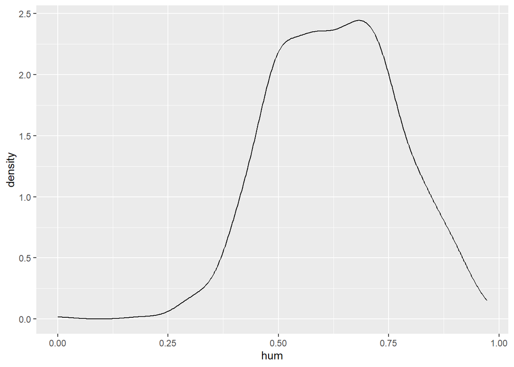

```r
ggplot(day_without_na, aes(x=hum))+
  geom_density()
```

Виден выброс в значениях влажности, значение равно 0. Отфильтруем значение влажности, равное 0.

```r
day_without_na <- filter(day_without_na, hum > 0.001)
```

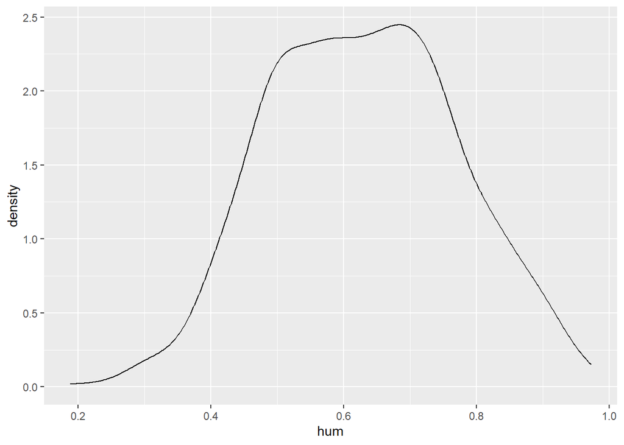

```r
ggplot(day_without_na, aes(x=hum))+
  geom_density()
```

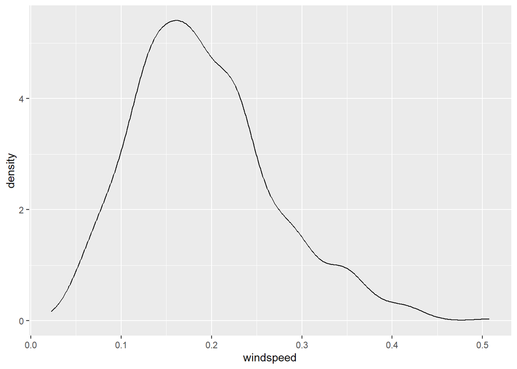

```r
ggplot(day_without_na, aes(x=windspeed))+
  geom_density()
```

Так же в значениях скорости ветра есть значения, дающие хвост, но это реальные значения замеренные в ветренные дни.

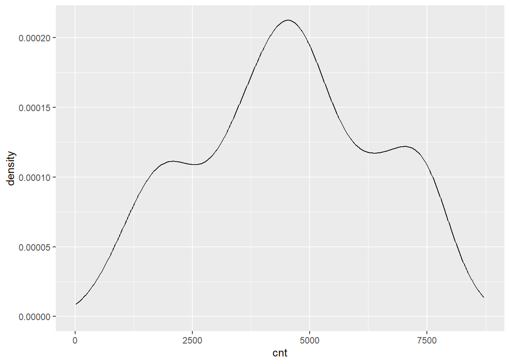

```r
ggplot(day_without_na, aes(x=cnt))+
  geom_density()
```

В Washington DC была подготовка к урагану Sandy и это видно по количеству пользователей в этот день, это ни как не отражается в данных, но дает небольшой выброс. Уберем из данных.

```r
day_without_na <- filter(day_without_na, cnt > 30)
```

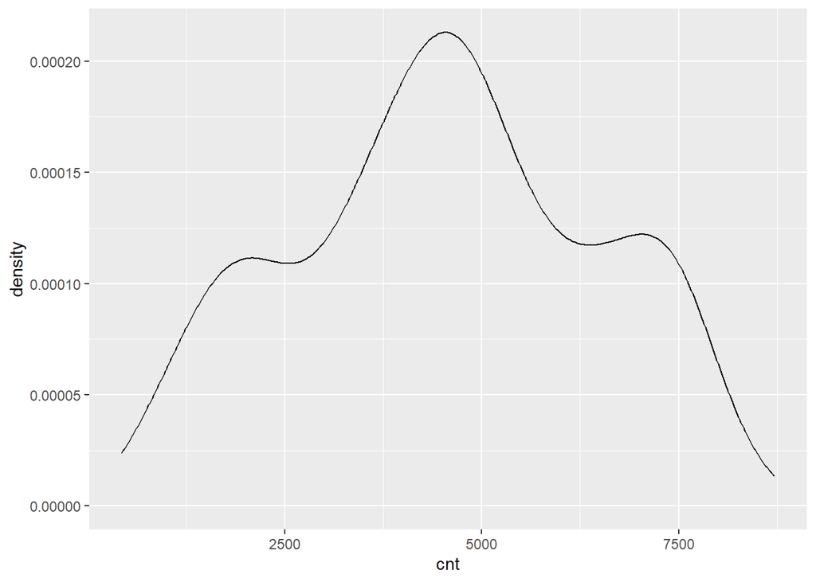

```r
ggplot(day_without_na, aes(x=cnt))+
  geom_density()
```

Xie (2023)

Xie, Yihui. 2023. *Knitr: A General-Purpose Package for Dynamic Report Generation in r*. https://yihui.org/knitr/.